# CS156 Assignment 1

**Armin Hamp**

*19 January, 2019*

```python
#load
import pandas as pd
import numpy as np
from datetime import datetime
from matplotlib import pyplot as plt
from sklearn import datasets, linear_model
from sklearn.metrics import mean_squared_error, r2_score, confusion_matrix
from sklearn.neighbors import KNeighborsClassifier
from sklearn.model_selection import train_test_split, GridSearchCV
import re
```

# Moore's Law

In this exercise, we were interested to observe whether Moore's Law holds for a singled out benchmark of the given dataset. We would accept Moore's law, if it was true that the CPU performance roughly doubled over every two years.

```python
df = pd.read_csv('benchmarks.txt', sep=",") #load data
```

```python
#extract date + base values for "hydro2d" benchmark
df=df.loc[df['benchName'] == "104.hydro2d"]

#extract date from testID
dates=df.iloc[:,0]
newdates=[]
for a in dates:
    t=re.sub("cpu95-","",a)
    t=t[:-6]
    newdates.append(t)
newdates=newdates[:542]
for i in range(len(newdates)):
    if newdates[i][0]=="9":
        original=newdates[i]
        newdates[i]="19"+original
df=df.iloc[:542,:]
df["date"]=newdates
df["date"]=pd.to_datetime(df["date"]) # convert to date format
df.head()
```

|  | testID | benchName | base | peak | date |
| --- | --- | --- | --- | --- | --- |
| 3 | cpu95-19990104-03254 | 104.hydro2d | 8.58 | 8.61 | 1999-01-04 |
| 29 | cpu95-19990118-03258 | 104.hydro2d | 8.39 | 8.65 | 1999-01-18 |
| 47 | cpu95-19990122-03281 | 104.hydro2d | 15.20 | 16.0 | 1999-01-22 |
| 57 | cpu95-19990122-03282 | 104.hydro2d | 26.80 | 28.3 | 1999-01-22 |
| 67 | cpu95-19990122-03283 | 104.hydro2d | 40.90 | 43.3 | 1999-01-22 |

```python
#process data for linear model
start_day=np.min(df["date"])
X=[(i-start_day).days for i in df.date]
X=np.reshape(X,(-1,1))
y=df["base"].values
y=np.reshape(y,(-1,1))
y=np.log(y)

#create and fit model
regr= linear_model.LinearRegression()
regr.fit(X,y)

#print output
print ("coefficient: %4f"%regr.coef_)
print ("intercept: %4f"%regr.intercept_)
print ("R^2: %4f"%regr.score(X,y))
```

```
coefficient: 0.001271
intercept: 1.330686
R^2: 0.339597
```

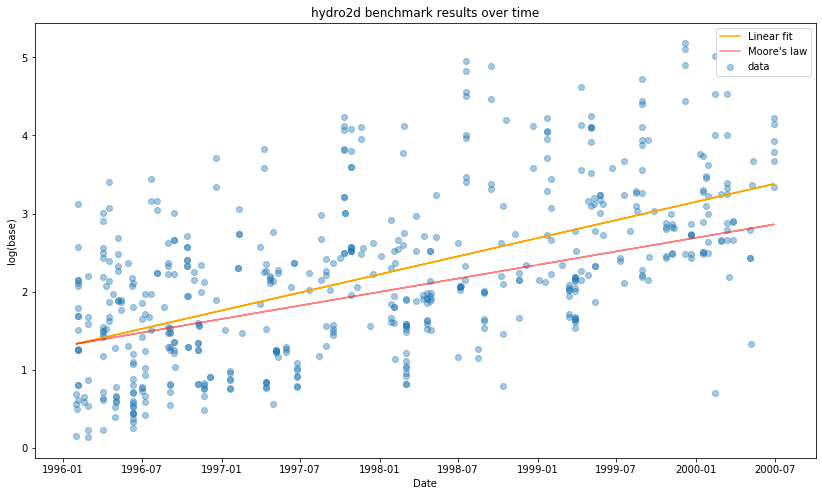

```python
#plot data
date=df["date"].values
base=df["base"].values
base=np.log(base) #log transform over y
fit=regr.predict(X) #extract fit from model
moore=[(2**(i/730)) for i in X] #moore's law
moore=np.log(moore)
moore=[i+regr.intercept_ for i in moore] #add intercept so plots are comparable

plt.figure(figsize=(14,8))
plt.ylabel("log(base)")
plt.xlabel("Date")
plt.title("hydro2d benchmark results over time")
plt.scatter(date,base,alpha=0.4, label="data")
plt.plot(date,fit, color="orange", label="Linear fit")
plt.plot(date,moore, color="red",label="Moore's law", alpha=0.5)
plt.legend()
plt.show()
```

As we can see in the plot above, the actual performance of CPUs at the hydro2d benchmark, over this timeframe, was better than Moore's Law would have predicted.

# MNIST Digits

I chose an 80:20 split of training vs test data, to provide enough for my k-Nearest Neighbor model to train on and ensure good performance on the test. I used a 6-fold cross validation (6 because it split the training data evenly) to find the best parameter value $k$.

```python
#load data for only two digits 0 & 1
digits = datasets.load_digits(n_class=2)

# turn the data in a (samples, feature) matrix:
n_samples = len(digits.images)
data = digits.images.reshape((n_samples, -1))

# Split data into train and test subsets (80/20 split)
X_train, X_test, y_train, y_test = train_test_split(
    data, digits.target, test_size=0.2, shuffle=False)
```

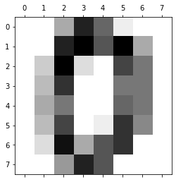

```python
#plot an example 0
plt.matshow(digits.images[0],cmap="binary")
plt.show()
```

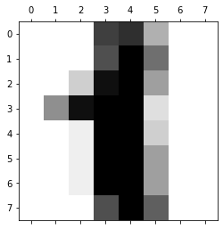

```python
#plot an example 1
plt.matshow(digits.images[1],cmap="binary")
plt.show()
```

```python
#create knn model
knn=KNeighborsClassifier()

#find the best value of k using 6-fold cross validation
param_k={'n_neighbors':np.arange(1,30)} #dict for all k values to test

#use gridsearch to test each k value
knn_grid=GridSearchCV(knn,param_k,cv=6, iid=True)

#fit model to train data
knn_grid.fit(X_train,y_train)

#check best parameters
knn_grid.best_params_
```

```
{'n_neighbors': 1}
```

Interestingly, the cross-validation showed us that the best $k$ is 1. This suggests that our data points for the digits 1 and 0 are far apart enough (very different), that a single neighbor proves to be a reliable predictor.

```python
#given the best parameters I'll use the split data to train
# and consequently test my knn model
k=1
clf=KNeighborsClassifier(k,weights='uniform')
clf.fit(X_train,y_train)
score=clf.score(X_test,y_test)
print("the model's accuracy is:", score)
```

```
the model's accuracy is: 1.0
```

```python
#confusion matrix
y_pred=clf.predict(X_test)
conf_mat=confusion_matrix(y_test, y_pred)
print("Confusion Matrix\n",conf_mat)
```

```
Confusion Matrix
 [[35  0]
 [ 0 37]]
```

The model has performed really well on our test set. It was able to tell the digits 0 and 1 in our test set with 100% accuracy.